# Lecture X: Hypothesis Testing

Kelly and Gallego

Our job isn’t to teach you stats; that’s Sunny’s job. But our job IS to teach you how to do stats in **R**, if that’s what you want to do. And testing hypotheses is what that’s all about.

###Testing Hypotheses

Hypothesis-testing forces you to be explicit about a question you’re asking.

Classically, for example, you’re taught the **t-test**. There, you’re comparing two sets of numbers to one another, and asking if one is bigger than the other. But of course one is bigger than the other, unless they’re the same. So you need a background expectation… a sense of how MUCH bigger one would have to be in order for you to think “Hey! That really *is* bigger… not just a little, but actually (say… I don’t know) *significantly* bigger.” A t-test lets you test the hypothesis that one set of numbers is bigger than the other, by comparing an observed difference to an expected difference.

So, classical hypothesis-testing entails:

1. First, having a hypothesis [usually – for philosophical reasons we can talk about – your hypothesis is that there is no difference between what you observed and what you expected… this is usually called the “null” hypothesis. It is your neutral, background expectation. It is what should happen by chance alone, if nothing interesting in the world were happening.]
2. Comparing your observation to a background expectation
3. Then deciding to (provisionally) accept or reject your hypothesis, given your comparison of observed vs. expected. [e.g., is this difference so big that I think it really matters? Or is it just a little, trivial difference?]

###Goddamn p-values You will note that we haven’t used the term *p-value* here. Except, damn. We just did. [Side-rant: people put entirely too much emphasis on p-values, and so we are attempting to free your mind from these annoying constraints. But we can’t ignore them entirely, because you will run into them, use them, etc. So, in the interest of dealing with the world such as it is…]

A p-value helps with this third step of testing a hypothesis: having compared observed and expected, is the difference between them so large that should I accept/reject my hypothesis?

A p-value is the probability of getting the result you did *by chance alone* (i.e., under the null hypothesis). [More technically, a p-value is the probability of getting the statistical result (e.g., difference between group-means, in the case of a t-test) or greater, under the given null statistical distribution… but you can see why we are trying not to talk like this. It is confusing.]

So, the larger your p-value, the more likely it is you are seeing a result you could have gotten by chance alone.

BUT!

- p-values have everying to do with sample size. Small numbers of samples mean it’s hard to confidently discern differences between expected and observed, even if those differences are real.
- There is nothing magical about p = 0.05. It is an arbitrary threshold scientists of many disciplines have coalesced around, reasoning that if something is likely to happen by chance alone only 5% of the time, we are reasonably happy calling it a real effect (rather than chance). But that doesn’t mean p = 0.06 *isn’t* a real effect, and it doesn’t mean p = 0.04 *is*.
- p-values are not a measure of truth. See points above.
- And more specifically, a p-value is NOT the probability that an alternative (non-null) hypothesis is true. See definition above.

[End of rant]

###Two-Sample t-test

So, assuming you justifiably want to do a t-test, how would you do that in **R**?

Let’s take two sets of numbers, the length of pirate swords in Tortuga (`x`) and in Barbados (`y`). The t-test asks whether the means of these two are different, given their variance.

```r
set.seed(49)  #for repeatability
  x <- rnorm(25, mean = 10, sd = 2)  #draw 25 random numbers from a normal distribution with mean 10 and standard deviation 2
  mean(x)
```

```
## [1] 10.19295
```

```r
  y <- rnorm(25, mean = 11, sd = 2)  #draw 25 random numbers from a normal distribution with mean 11 and standard deviation 2
  mean(y)
```

```
## [1] 10.6667
```

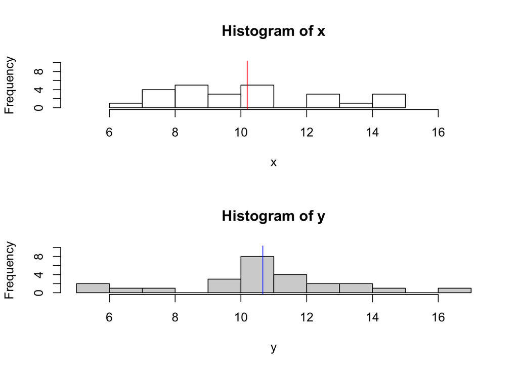

```r
#visualize these distributions in a histogram
par(mfrow=c(2,1))
    hist(x, breaks = 10, ylim = c(0,10), xlim = c(5,17))
      abline(v=mean(x), col="red")

    hist(y, col="lightgrey", breaks = 10, ylim = c(0,10), xlim = c(5,17))
      abline(v=mean(y), col="blue")
```

The mean of `y` is slightly higher than the mean of `x` , as we expect. But is it statistically significantly different?

```r
t.test(x, y)  #t-test is trivially easy to run in R; it's built-in.
```

```
##
##  Welch Two Sample t-test
##
## data:  x and y
## t = -0.6953, df = 47.685, p-value = 0.4902
## alternative hypothesis: true difference in means is not equal to 0
## 95 percent confidence interval:
##  -1.8439685  0.8964642
## sample estimates:
## mean of x mean of y
##  10.19295  10.66670
```

```r
#note there are options for one-sample t-tests, one-tailed paired t-tests, etc.  see ?t.test
```

The results here provide the statistic (`t`), the p-value, a confidence interval, etc. By default, the results are printed to the screen, but you can store the results in an object, if you want.

```r
t.test.results <- t.test(x,y)
```

You can then grab elements of this object if you like. For example, if you just want the p-value, you can call `t.test.results$p.value`.

[Note here: the means of our samples really WERE different… they were 10 and 11, respectively. Had our sample sizes been larger, we would have detected that difference with a p < 0.05. This is a great illustration of the idea that p-values are not truth.]

###Other tests of difference between two samples

**R** has lots of built-in statistical tests. For example:

```r
wilcox.test(x,y)  #super useful; doesn't assume normal distributions
```

```
##
##  Wilcoxon rank sum test
##
## data:  x and y
## W = 262, p-value = 0.335
## alternative hypothesis: true location shift is not equal to 0
```

```r
ks.test(x, y)  #Kolmogorov-Smirnov test; similar.
```

```
##
##  Two-sample Kolmogorov-Smirnov test
##
## data:  x and y
## D = 0.24, p-value = 0.4755
## alternative hypothesis: two-sided
```

```r
#you get the point.
```

###Correlation and Linear Regression

Perhaps the most common test of a hypothesis is one you don’t necessarily think of as being a test. You just want to know if two variables are correlated. [I know, I know. I’m using “regression” and “correlation” somewhat interchangably here. Correlation is when two things aren’t causally linked… A goes up as B goes up, and we don’t care why. Regression is when we have specified some relationship between A and B, calling one “independent/predictor” and the other “dependent/response”. Fine. But they’re pretty much the same thing as a practical matter.]

This is one thing that Excel does well, in my opinion: it’s easy to plot data, get the equation of the best-fit line, and even see the $R^2$ value if you want to. **R** is less straightforward here, but more powerful in the sense that it lets you look under the hood.

Let’s use some data from the `yarrr` package, called `diamonds`, and begin by looking at the relationship between value and weight.

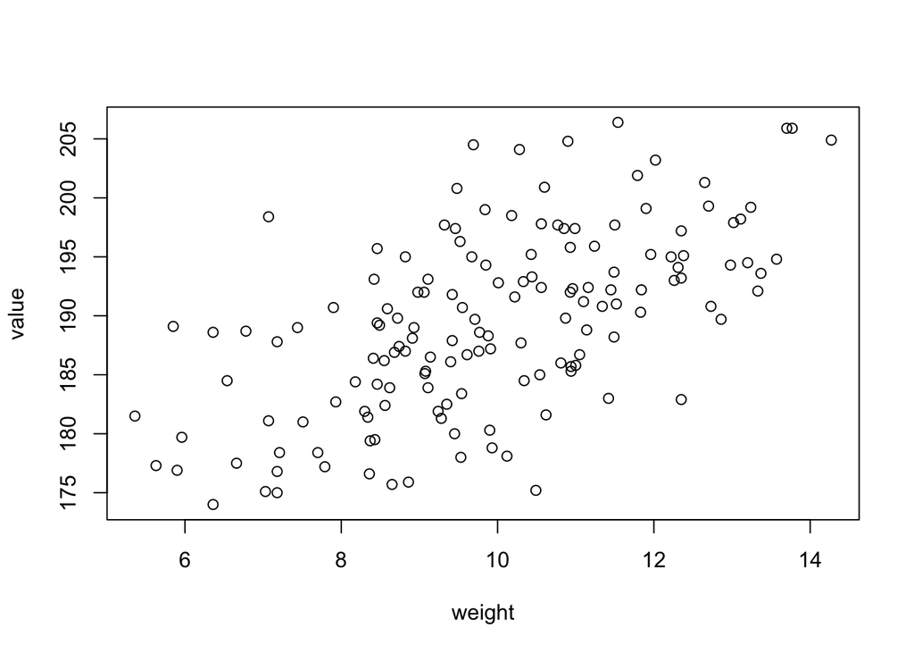

```r
plot (value~weight, data=diamonds)
```

It seems likely there’s a relationship here, right? [And further, it seems likely that weight influences value, and not the other way around, so weight is our independent/predictor variable, if you’re keeping track.]

If we just care about correlation – rather than linear regression – we’re not trying to fit the equation of a line to the data, but rather asks whether the association between one variable and the other is greater than would be expected by chance alone. Then, we can just use `cor.test`. [Analogous to the built-in tests above.]

```r
cor.test(diamonds$weight, diamonds$value) #Pearson, by default, but Kendall and Spearman are also available. The give similar results.
```

```
##
##  Pearson's product-moment correlation
##
## data:  diamonds$weight and diamonds$value
## t = 9.2476, df = 148, p-value = 2.36e-16
## alternative hypothesis: true correlation is not equal to 0
## 95 percent confidence interval:
##  0.4926788 0.6977498
## sample estimates:
##       cor
## 0.6051585
```

```r
#note: if you just want the correlation coefficient, and not to do the test, you can just use
cor(diamonds$weight, diamonds$value, method = "pearson")
```

```
## [1] 0.6051585
```

If we care about the slope of the line, we want to fit a **linear model** to the data, using **R**’s `lm()` function.

We do this in just the same way as we plot the data, but instead of `plot()`, we use `lm()`. And we’ll save the output to an object.

```r
lm.result <- lm(value~weight, data=diamonds)  #yvariable~xvariable is the formula
summary(lm.result) #a useful way to look at the results
```

```
##
## Call:
## lm(formula = value ~ weight, data = diamonds)
##
## Residuals:
##      Min       1Q   Median       3Q      Max
## -15.6545  -4.1676  -0.3392   4.4721  15.7596
##
## Coefficients:
##             Estimate Std. Error t value Pr(>|t|)
## (Intercept) 165.6598     2.6198  63.233  < 2e-16 ***
## weight        2.4018     0.2597   9.248 2.36e-16 ***
## ---
## Signif. codes:  0 '***' 0.001 '**' 0.01 '*' 0.05 '.' 0.1 ' ' 1
##
## Residual standard error: 6.134 on 148 degrees of freedom
## Multiple R-squared:  0.3662, Adjusted R-squared:  0.3619
## F-statistic: 85.52 on 1 and 148 DF,  p-value: 2.36e-16
```

There’s a lot of information here. For the moment, let’s focus on `Coefficients`. The first column of numbers gives you the estimates. So where the equation of a line is $y=\beta_{0}+\beta_{1}x_{1}+\beta_{2}x_{2}+...\beta_{n}x_{n}$

these are the intercept ($\beta_{0}$) and the slope ($\beta_{1}$) of the line. The 4th column `Pr(>|t|)` gives you the p-values for each of these. The p-value for the slope is also repeated at the bottom of the output, for clarity.

So the slope of the best-fit line is y= 165.66 + 2.4x, and this model explains about 37% of the variance in the underlying data.

```r
  #note that using plot() on just the linear model result doesn't do what you'd expect... it doesn't plot the data and the best-fit line.  Instead, it uses plots to help you evaluate the model fit.  This is more serious stats than you might be interested in, but...

plot(lm.result)  #gives you 4 plots to help assess whether your model violates the core assumptions of linear regressions...
```

[output not shown]

Note that you can use `predict()` to predict the value of a diamond, given the weight, under the model. For example:

```r
#predict the value of diamonds of weights 190, 200, and 201 grams
predict(lm.result, newdata = data.frame(weight =c(190, 200 ,210)))
```

```
##        1        2        3
## 621.9980 646.0158 670.0336
```

####Plotting linear regressions

… is pretty easy, but not as easy as in Excel. First you plot the data, then you add the info from the linear model.

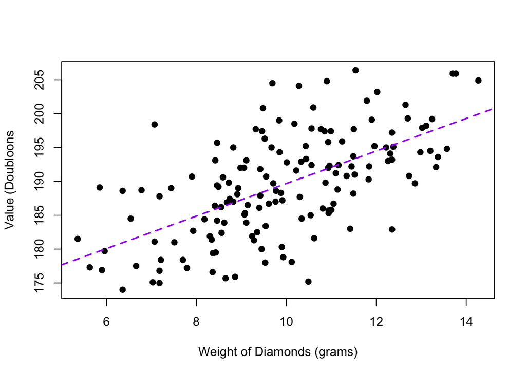

```r
plot (value~weight, data=diamonds,
      pch = 19, xlab = "Weight of Diamonds (grams)", ylab = "Value (Doubloons") #here, let's use filled-in dots and label the axes appropriately

  #now we add the best-fit line from the linear model we saved above
  abline(lm.result,
         col = "purple", #we'll color it purple
         lwd = 2, #and make it thick (lwd, for "line width")
         lty = 2)   #dashed (lty = 2, for "line type")
```

```r
  #confidence intervals would be nice to add, which is easy in ggplot, but hard in base R.  See this, if you're interested: https://stackoverflow.com/questions/43692394/shading-confidence-intervals-in-r-base-r-if-possible
```

###Multiple Linear Regression

So we’ve answered the question of how diamond weight is associated with price.

Perhaps you’re interested in how the clarity AND the weight of a diamond affect its value. Easy. Just like single linear regression.

```r
mult.lm.result <- lm(value ~ weight + clarity, data = diamonds)
summary(mult.lm.result)  #here's the same output, but with another term... the estimate for clarity as well as weight and the intercept.
```

```
##
## Call:
## lm(formula = value ~ weight + clarity, data = diamonds)
##
## Residuals:
##     Min      1Q  Median      3Q     Max
## -10.034  -3.802  -0.196   3.207  11.166
##
## Coefficients:
##             Estimate Std. Error t value Pr(>|t|)
## (Intercept)  145.446      2.795   52.04   <2e-16 ***
## weight         2.219      0.199   11.15   <2e-16 ***
## clarity       22.036      2.129   10.35   <2e-16 ***
## ---
## Signif. codes:  0 '***' 0.001 '**' 0.01 '*' 0.05 '.' 0.1 ' ' 1
##
## Residual standard error: 4.681 on 147 degrees of freedom
## Multiple R-squared:  0.6334, Adjusted R-squared:  0.6284
## F-statistic:   127 on 2 and 147 DF,  p-value: < 2.2e-16
```

Plotting multiple linear regression makes little sense beyond 2 independent variables (which you can plot in 3 dimensions… but do you really need to?). So we’re not going to do it here. But the lesson is plain: multiple linear regression is super easy; you can just add a term to your existing `lm()`.

###ANOVA (Analysis of Variance) Spoiler alert: ANOVA is secretly the same thing as multiple linear regression! Why no one told me this for a couple of decades, I have no idea.

The idea behind the two techniques is the same, if you think about it:  
* In multiple linear regression, you want to know how each of the factors affects the outcome. * In ANOVA, you want to know how each of the factors affects the outcome, and you do this by comparing the difference in means between groups. Sort of like a t-test for multiple groups. (The bigger idea here is to partition the variance in your sample according to group… for example, what fraction of variance in the price of diamonds is due to variance in weight? clarity?)

```r
#make an ANOVA object
anova.result <- aov(value ~ weight + clarity, data = diamonds)
  summary(anova.result)
```

```
##              Df Sum Sq Mean Sq F value Pr(>F)
## weight        1   3218    3218   146.8 <2e-16 ***
## clarity       1   2347    2347   107.1 <2e-16 ***
## Residuals   147   3221      22
## ---
## Signif. codes:  0 '***' 0.001 '**' 0.01 '*' 0.05 '.' 0.1 ' ' 1
```

```r
  coefficients(anova.result)  #note this is the same as
```

```
## (Intercept)      weight     clarity
##  145.446330    2.218574   22.036231
```

```r
  coefficients(mult.lm.result)  #!
```

```
## (Intercept)      weight     clarity
##  145.446330    2.218574   22.036231
```

```r
  total.variance <- sum(as.data.frame(summary(anova.result)[[1]])[,2]) #sum up the sums of squares

  #fraction of variance explained by each of the factors (akin to the Rsquared value of the lm):

  SumSquares <- data.frame(
    factors = row.names(as.data.frame(summary(anova.result)[[1]])),
    Rsquared =as.data.frame(summary(anova.result)[[1]])[,2] / total.variance
    )

  sum(SumSquares[1:2, 2])  #the same Rsquared value we get from the multiple linear model
```

```
## [1] 0.6333847
```

And just to put these results in visual context…

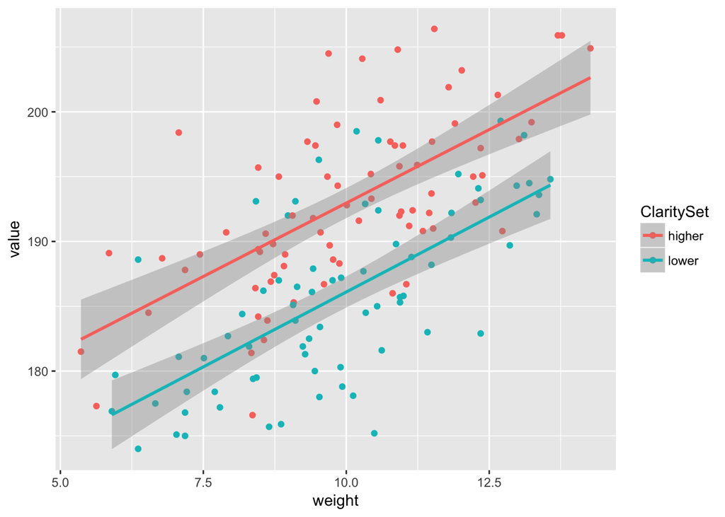

```r
diamonds$ClaritySet <- ifelse(diamonds$clarity <= mean(diamonds$clarity), "lower", "higher")  #create bins of clarity above and below mean clarity

ggplot(diamonds, aes(y = value, x = weight, color = ClaritySet))+
  geom_point()+
  geom_smooth(method = "lm")
```

###Appendix: the package broom